# 2119317_EMATM0061A

Lakshmikanth Loya

07/01/2022

# Importing all the libraries required

```r
library(tidyverse)
library(Stat2Data)
library(scales)
```

# A1

*Importing the dataset to R.

- finding the number of rows and columns of the given dataset

```r
finance_data_original <- read.csv(file = "finance_data_EMATM0061.csv") #importing the data sets

nrow(finance_data_original)
```

```
## [1] 1051
```

```r
ncol(finance_data_original)
```

```
## [1] 30
```

```r
#finding the number of rows and columns of the given dataset, the above dataset has 1051 rows and 30 columns
```

# A2

- Generate a new data frame called “finance_data” which is a subset of the “finance_data_original” data frame with the same number of rows, but only six columns
- selecting and renaming a few certain columns of finance data

```r
finance_data <- finance_data_original %>%
  select(state_year_code,Details.Education.Education.Total,Details.Health.Health.Total.Expenditure,Details.Transportation.Highways.Highways.Total.Expenditure,Totals.Revenue,Totals.Expenditure)  %>%
  rename(education_expenditure = Details.Education.Education.Total, health_expenditure = Details.Health.Health.Total.Expenditure, transport_expenditure = Details.Transportation.Highways.Highways.Total.Expenditure, totals_revenue = Totals.Revenue, totals_expenditure = Totals.Expenditure)

#displaying the specific renamed of finance_data
finance_data %>%
  select(state_year_code,education_expenditure,health_expenditure) %>%
  head(5)
```

```
##   state_year_code education_expenditure health_expenditure
## 1   ALABAMA__1992               3570524                 NA
## 2   ALABAMA__1993               3663465                 NA
## 3   ALABAMA__1994               3969277             487044
## 4   ALABAMA__1995               4400912             491648
## 5   ALABAMA__1996               4872259             514380
```

# A3

- Creating a new column within the “finance_data” data frame called “totals_savings” which is equal to the difference between revenue and the expenditure i.e, the elements of the “totals_savings” column are equal to elements within the “totals_revenue” minus the element within the “totals_expenditure” column, for each row.

```r
#creating a new column named total_savings
finance_data <- finance_data %>%
  mutate(totals_savings = totals_revenue - totals_expenditure)
head(finance_data,5)
```

```
##   state_year_code education_expenditure health_expenditure
## 1   ALABAMA__1992               3570524                 NA
## 2   ALABAMA__1993               3663465                 NA
## 3   ALABAMA__1994               3969277             487044
## 4   ALABAMA__1995               4400912             491648
## 5   ALABAMA__1996               4872259             514380
##   transport_expenditure totals_revenue totals_expenditure totals_savings
## 1                694874       10536166            9650515         885651
## 2                856228       11389335           10242374        1146961
## 3                883852       11599362           10815221         784141
## 4                924411             NA           11541881             NA
## 5                881381       12741148                 NA             NA
```

```r
finance_data %>%
  select(state_year_code,totals_revenue,totals_expenditure,totals_savings) %>%
  head(3)
```

```
##   state_year_code totals_revenue totals_expenditure totals_savings
## 1   ALABAMA__1992       10536166            9650515         885651
## 2   ALABAMA__1993       11389335           10242374        1146961
## 3   ALABAMA__1994       11599362           10815221         784141
```

# A4

- Dividing the “state_year_code” column into two separate columns, a “state” column and a “year” column which replace the original “state_year_code” column.
- converting the first letter of state into uppercase and rest lowercase

```r
#seprating the state and year column
finance_data <- finance_data %>%
  separate(state_year_code,into=c("state","year"),sep = '__')


#converting the first letter of state into uppercase and rest lowercase
finance_data$state = str_to_title(finance_data$state)
head(finance_data)
```

```
##     state year education_expenditure health_expenditure transport_expenditure
## 1 Alabama 1992               3570524                 NA                694874
## 2 Alabama 1993               3663465                 NA                856228
## 3 Alabama 1994               3969277             487044                883852
## 4 Alabama 1995               4400912             491648                924411
## 5 Alabama 1996               4872259             514380                881381
## 6 Alabama 1997               5175279             566651                837255
##   totals_revenue totals_expenditure totals_savings
## 1       10536166            9650515         885651
## 2       11389335           10242374        1146961
## 3       11599362           10815221         784141
## 4             NA           11541881             NA
## 5       12741148                 NA             NA
## 6       14007883                 NA             NA
```

```r
finance_data %>%
  select(state,year,totals_revenue,totals_expenditure,totals_savings) %>%
  head(3)
```

```
##     state year totals_revenue totals_expenditure totals_savings
## 1 Alabama 1992       10536166            9650515         885651
## 2 Alabama 1993       11389335           10242374        1146961
## 3 Alabama 1994       11599362           10815221         784141
```

# A5

- genrate a plot which displays the total revenue (“total_revenue”) as function of the year (“year”) for the following four states: Louisiana, Montana, Mississippi and Kentucky.
- creating a temporary dataframe to plot a graph for specified states

```r
#creating a temporary dataframe to plot a graph for specified states
finance_data_plot <- finance_data%>%
  select(year,totals_revenue,state)%>%
  filter(state == "Louisiana"| state =="Montana"| state =="Mississippi"|state =="Kentucky")
#finance_data_plot  #checking our data frame once
#in the above step we are filtering the states that are desired for plotting a graph



finance_data_plot$year <- as.numeric(finance_data_plot$year)
#since the column "year" is of type "char" so we convert it into numeric to plot a graph
mode(finance_data_plot$year) #checking whether the value of year changed to numeric from char
```

```
## [1] "numeric"
```

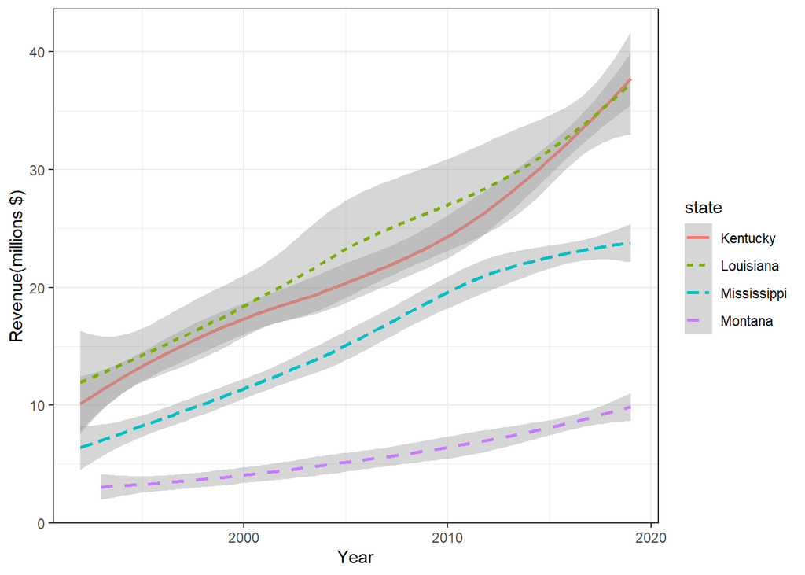

```r
ggplot(data = finance_data_plot,aes(x=year,y=totals_revenue,color=state,linetype = state))+xlab("Year")+ylab("Revenue(millions $)")+
  scale_y_continuous(labels = label_number(scale = 1e-6))+geom_smooth()+theme_bw()
```

```r
#labeling the numbers to millions because the number are too great for the graph
```

# A6

*Creating a function called get_decade() to convert all the years to their respective decades.* Using the get_decade() function to add a new column to the “finance_data” data frame called “decade” *which gives the decade corresponding to the year column.

```r
#declaring function get decade to convert all the years to their respective decades
get_decade <- function(year){
  if(year%%10 == 0){
  }
  else{
    year = year-(year%%10)
  }
  return(year)
}

finance_data$year <- as.numeric(finance_data$year) #changing the value of year to numeric since it is in char and our function decade works for numeric values.
mode(finance_data$year) #checking whether the value of year changed to numeric from char
```

```
## [1] "numeric"
```

```r
decade <- map_dbl(finance_data$year,get_decade)
#applying decade function to the "year" column of finance_data

finance_data <- finance_data %>%
  mutate(decade)

finance_data %>%head(4)
```

```
##     state year education_expenditure health_expenditure transport_expenditure
## 1 Alabama 1992               3570524                 NA                694874
## 2 Alabama 1993               3663465                 NA                856228
## 3 Alabama 1994               3969277             487044                883852
## 4 Alabama 1995               4400912             491648                924411
##   totals_revenue totals_expenditure totals_savings decade
## 1       10536166            9650515         885651   1990
## 2       11389335           10242374        1146961   1990
## 3       11599362           10815221         784141   1990
## 4             NA           11541881             NA   1990
```

```r
finance_data %>%
  group_by(state,decade) %>%
  filter(decade==2000) %>%
  summarise(mean_average_savings = mean(totals_savings,na.rm= TRUE)) %>%
  arrange(desc( mean_average_savings)) %>%
  head(3)# using head only till 3 since highest mean average of 3 states was asked and we got the highest by arranging the rows in descending order
```

```
## # A tibble: 3 x 3
## # Groups:   state [3]
##   state      decade mean_average_savings
##   <chr>       <dbl>                <dbl>
## 1 Texas        2000             4103352.
## 2 Ohio         2000             3025980
## 3 California   2000             2510483.
```

# A7

- Generate a summary data frame from the “finance_data” data frame called “alaska_summary” with certain specific properties.

```r
alaska_summary <- finance_data %>%
  select(everything()) %>%
  filter(state == "Alaska" & decade >=1990 | decade <= 2010) %>%
  group_by(decade) %>%
  summarise(ed_mn = mean(education_expenditure,na.rm=TRUE), ed_md = median(education_expenditure,na.rm=TRUE), he_mn = mean(health_expenditure,na.rm=TRUE), he_md = median(health_expenditure,na.rm=TRUE), tr_mn = mean(transport_expenditure,na.rm=TRUE), tr_md = median(transport_expenditure,na.rm=TRUE))

alaska_summary
```

```
## # A tibble: 3 x 7
##   decade     ed_mn    ed_md    he_mn  he_md    tr_mn    tr_md
##    <dbl>     <dbl>    <dbl>    <dbl>  <dbl>    <dbl>    <dbl>
## 1   1990  6039513. 3666635   714129. 344200 1348194.  921885
## 2   2000  7998473. 5547702   975997. 500735 1649026. 1341643
## 3   2010 13383237. 9331076. 1153090. 486653 2462501. 1574268.
```

# A8

- Removing all the NaaN/Missing values by using the function “impute_by_median()”.
- generating a subset of your “finance_data” data frame called “idaho_2000” which contains all those rows in
- which the state column takes the value “Idaho” and the “decade” column takes the value “2000” and includes
- the columns “year”, “education_expenditure”, “health_expenditure”, “transport_expenditure”, “totals_revenue”,
- “totals_expenditure”, “totals_savings” (i’.e. all columns except “state” and “decade”).
- Removing all the NaaN values using the “impure_by_median()”.
- Displaying a subset of your “idaho_2000_imputed” data frame consisting of the first five rows and the four columns
- “year”, “health_expenditure”, “education_expenditure” and “totals_savings”.

```r
impute_by_median<-function(x){
m_med<-median(x,na.rm=1) # first compute the mean of x
impute_f<-function(z){ # coordinate-wise imputation
if(is.na(z)){
return(m_med) # if z is na replace with mean
}else{
return(z) # otherwise leave in place
}
}
return(map_dbl(x,impute_f)) # apply the map function to impute across vector
}

idaho_2000<-finance_data%>%
  filter(state=="Idaho"& decade==2000)%>%
  select(-state,-decade)
idaho_2000
```

```
##   year education_expenditure health_expenditure transport_expenditure
## 1 2000               1663980              98510                470498
## 2 2001               1768837             103705                501659
## 3 2002                    NA                 NA                499916
## 4 2003               1886421             116088                521746
## 5 2004                    NA             131165                524242
##   totals_revenue totals_expenditure totals_savings
## 1        5576284            4492552        1083732
## 2        5286097            4951659         334438
## 3        4487672            5234047        -746375
## 4        5492993                 NA             NA
## 5        7112364            5762624        1349740
```

```r
table(is.na(idaho_2000))#finding the total number of null values on the dataframe
```

```
##
## FALSE  TRUE
##    30     5
```

```r
idaho_2000_imputed <- map_df(idaho_2000,impute_by_median)#removing the numm values


idaho_2000_imputed%>%select(year, health_expenditure, education_expenditure,totals_savings)%>%


  head(5)
```

```
## # A tibble: 5 x 4
##    year health_expenditure education_expenditure totals_savings
##   <dbl>              <dbl>                 <dbl>          <dbl>
## 1  2000             98510                1663980        1083732
## 2  2001            103705                1768837         334438
## 3  2002            109896.               1768837        -746375
## 4  2003            116088                1886421         709085
## 5  2004            131165                1768837        1349740
```